# Part II - Ford GoBike System Dataset Exploration

## by Bazarov Mehrol

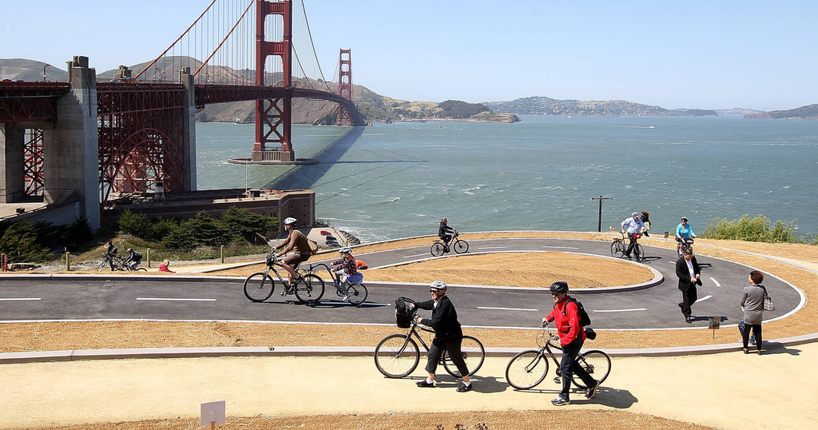

## Investigation Overview

> Throughout my exploration of the Ford GoBike System dataset, I made several key findings:

> `User Types:` As I analyzed the dataset, I discovered that the majority of users were subscribers, indicating a strong base of regular users who use the bike-sharing system more frequently. Customers, on the other hand, represented a smaller portion of the user base, suggesting that they may be more casual or occasional users of the system.

> `Ride Durations:` I found interesting patterns in ride durations. Subscribers generally had shorter ride durations compared to customers, which aligns with the assumption that subscribers might use the system more frequently for shorter trips. Conversely, customers had longer and more variable ride durations, indicating different usage patterns, potentially for leisure or recreational purposes.

> `Gender Distribution:` Analyzing the dataset, I observed a gender imbalance in the bike-sharing system. There were significantly more male users compared to female and other genders. This gender disparity highlights potential areas for improvement to encourage greater diversity and inclusivity within the bike-sharing community.

> `Popular End Stations:` By exploring the data, I identified the top 10 popular end stations in the bike-sharing system. These stations, such as "San Francisco Caltrain Station 2 (Townsend St at 4th St)" and "Market St at 10th St," exhibited high usage and demand, serving as popular destinations for bike rides.

## Dataset Overview

> The dataset used for this presentation is the Ford GoBike System Data, which contains information about individual rides made in a bike-sharing system covering the greater San Francisco Bay area. The dataset includes various attributes such as ride duration, user type, member gender, start and end station information, and more.

## Visualization 1 - How does the number of rides vary across different user types?

### Observation:

The bar plot displays the number of rides recorded for each user type. Subscribers have a significantly higher number of rides compared to customers. This suggests that the bike-sharing system has a large base of subscribers who use it more frequently.

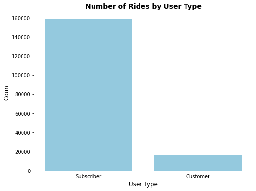

## Visualization 2 - Which end stations are the most popular?

### Observation:

The visualization displays the top 10 popular end stations in the bike-sharing system. The bar plot provides insights into the frequency of usage for each end station. Based on the number of rides, we can determine the popularity of different end stations. The station with the highest count, "San Francisco Caltrain Station 2 (Townsend St at 4th St)," is the most frequently used end station, followed by "Market St at 10th St" and "Montgomery St BART Station (Market St at 2nd St)." These stations serve as popular destinations for bike rides, indicating high demand and usage.

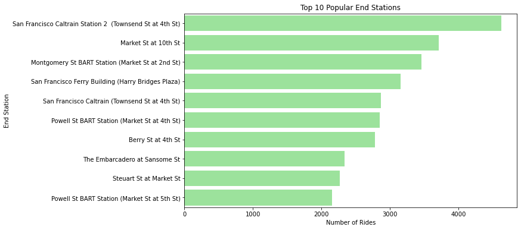

## Visualization 3 - What is the distribution of member genders in the dataset?

### Observation:

The count plot illustrates the number of rides recorded for each member gender. The dataset contains a significantly higher number of male users compared to female and other genders. This indicates a gender imbalance in the bike-sharing system, with males being the predominant users.

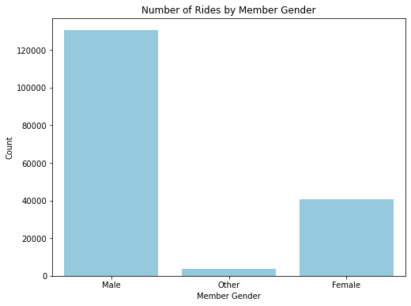

## Visualization 4 - What is the distribution of member birth years?

### Observation:

The histogram represents the distribution of member birth years. The majority of users have birth years between 1980 and 2000, with the highest frequency observed around the late 1980s to early 1990s.

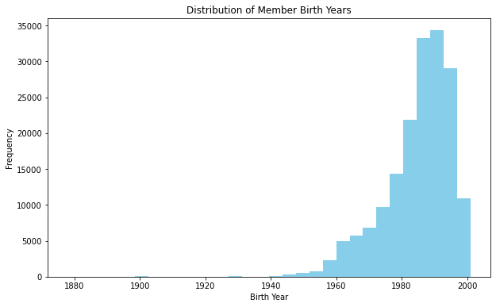

## Visualization 5 - Is there a relationship between the top 10 start stations and the user type?

### Observation:

The stacked bar plot visualizes the relationship between the top 10 start stations and user types. Here are the observations:

Market St at 10th St: The majority of rides from this start station are by subscribers, indicating that it is a popular choice among regular users of the bike-sharing system. The number of customer rides is relatively lower in comparison.

San Francisco Caltrain Station 2 (Townsend St at 4th St): Similar to the previous start station, subscribers make up the majority of rides, suggesting a preference among regular users. The number of customer rides is relatively lower.

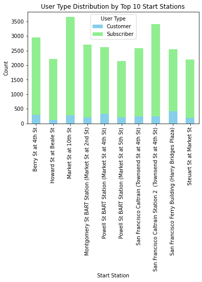

## Visualization 6 - Are there any relationships between the start day of the week, user type, and the duration of rides?

### Observation:

The box plot visualizes the relationship between the start day of the week, user type, and the duration of rides. Here are the observations:

Overall, the box plot reveals that ride durations are influenced by both the start day of the week and the user type. Subscribers tend to have shorter and more consistent ride durations, while customers have longer and more variable ride durations. Weekends (Saturday and Sunday) exhibit slightly longer ride durations for both user types, possibly due to different usage patterns and leisurely rides during weekends.

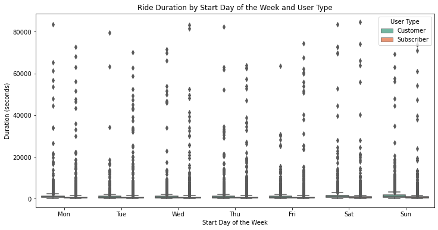

## Visualization 7 - How does the ride duration vary across different user types and member genders?

### Observation:

The heatmap visualizes the mean ride duration across different user types and member genders. Here are the observations:

-Male subscribers have the shortest average ride duration, followed by female subscribers. Other customers have the longest average ride duration among all categories.

-The shortest ride durations are observed for male subscribers, with an average duration of around 616 seconds (10 minutes). Female subscribers have slightly longer average ride durations of approximately 696 seconds (12 minutes). Other customers have the longest average ride duration, exceeding 1602 seconds (26 minutes).

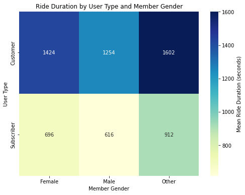

## Visualization 8 - How does the ride duration vary across different user types, the day of the week?

### Observation:

For both subscribers and customers, ride durations are generally longer on weekends (Saturday and Sunday) compared to weekdays.

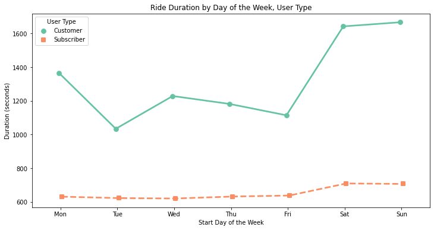